# Simulation study of multi-trait program correspondence

## How to read this document

**The question.** gpmapr finds *programs* – groups of loci that behave alike across hundreds of background GWAS – separately for each target trait. The real-data study (`investigation-multitrait-programs.Rmd`) then links two traits’ programs by the **loci they share**, with `compare_program_pairs_loadings()`, and takes the direction of each link from `module_rg()`. This document checks that pipeline on simulated data where the answer is known. Two traits share **one** program, and we ask three things:

1. Is the shared program **found** in each trait’s own fit, and if it is thrown away, which validation gate threw it away?
2. Is it **linked** across the two traits, as the SNP overlap between the two copies falls from 1 to 0.1?
3. Is the link given the right **direction**: concordant (raises both traits) or antagonistic (raises one, lowers the other)?

Programs are linked on loci only. Background-study profiles and annotations play no part in forming a link; on real data they are used afterwards, to describe programs that are already linked.

**What happens in one simulated replicate.**

1. **Simulate** two target traits with `simulate_trait_pair()`. Each is a matrix of background studies x loci (z-scores). One program is planted in both traits, and `K_specific` programs in each trait alone.
2. **Fit each trait on its own** with EBMF (`run_univariate_clustering()`), exactly as the real-data analysis does. EBMF knows nothing about the other trait.
3. **Validate** every fitted program (`summarise_ebmf_programs()`), with the same gates used on real data, and record each program’s `status`.
4. **Link** the programs across traits (`compare_program_pairs_loadings()`), which also runs `module_rg()` on every link. This is done twice: on every fitted program, and on the valid programs only, so the effect of the gates can be seen.
5. **Score** discovery, links and direction against what was planted.

The whole replicate is repeated `n_sim` times per setting, and each table reports the mean with its Monte Carlo standard error in parentheses.

**Glossary.**

- **Program**: one EBMF factor: a set of loci (its SNP loadings) together with the background studies that load on it.
- **SNP overlap**: the fraction of the shared program’s loci that are the same locus (coloc group) in both traits. At 1 the two copies act at exactly the same loci; at 0.1 they share 4 of their 36.
- **Driver study**: a background study planted as part of a program. The shared program has the same driver studies in both traits.
- **Common allele frame**: effects are generated as they are reported, for one fixed allele per locus. A driver study has the same sign at a shared locus in both traits, because it is the same GWAS. An antagonistic program has opposite-sign **target** effects at its loci.
- **Orientation**: before fitting, every locus is flipped to its own target trait’s risk-increasing allele, as on real data. This is where antagonism reaches the fit: in the antagonistic trait the driver studies end up negative.
- **status**: the validation outcome of a fitted program: `valid` when its confidence tier is high or medium, otherwise the tier (`low`, or `single_trait` when its trait loadings rest on essentially one trait).
- **Primary / candidate link**: a *primary* link is a mutual best match between two significant programs, the strict one-to-one claim. A *candidate* link is any other pair whose own FDR clears the threshold.
- **Recall**: the fraction of planted shared programs linked (here 0 or 1 per replicate).
- **Precision**: the fraction of reported links that are real.
- **Sign accuracy**: among real links, the fraction called in the planted direction.
- **SNP precision / recall**: for a resolved program, the share of its high-confidence SNPs that were planted, and the share of the planted SNPs it recovers.
- **MCSE**: Monte Carlo standard error. It measures how precisely `n_sim` replicates pin down the reported mean, not biological variability.

Active settings. ebmf_settings_signature identifies the shared analysis settings this run resolved from _ebmf_settings.yml; two studies carrying the same signature were run on the same discovery settings.

| parameter | value |
| --- | --- |
| n_loci_per_trait | 200 |
| n_shared_loci | 80 |
| K_specific | 2 |
| module_size | 36 |
| n_drivers_per_program | 8 |
| profile_overlap | 1 |
| n_background_traits | 300 |
| effect_size | 6 |
| locus_effect_sd | 0.5 |
| noise_sd | 1 |
| p_structural_zero | 0 |
| p_active_background | 0.02 |
| background_sparsity_sd | 1.2 |
| background_effect_scale | 0.5 |
| background_corr | 0 |
| snp_pleiotropy_sd | 0 |
| snp_overlap | 0.1, 0.2, 0.33, 0.66, 1 |
| directions | concordant, antagonistic |
| stability_n_rep | 2 |
| frac_traits | 0.8 |
| stability_top_n | 20 |
| n_sim | 2 |
| n_perm | 300 |
| fdr_threshold | 0.05 |
| quick | TRUE |
| ebmf_settings_signature | compress_method=asinh; compress_scale=5; ebmf_backfit=TRUE; ebmf_greedy_Kmax=100; ebmf_lfsr_threshold=0.05; ebmf_magnitude_threshold=0.5; ebmf_prior=point_laplace; high_connectedness=0.4; high_similar… |

## Simulation design (ADEMP)

Following Morris, White and Crowther (2019, *Statistics in Medicine* 38:2074-2102), as the univariate studies do.

**Aims.** (i) Measure how often a program shared by two traits survives each trait’s own fit and validation. (ii) Measure how often it is linked across the traits as a function of SNP overlap. (iii) Measure whether the direction of the link is called correctly, by the concordance sign and by `module_rg()`. (iv) Measure false links when nothing is shared.

**Data-generating mechanism.** `simulate_trait_pair()` with `K_shared = 1`. Each trait carries `n_loci_per_trait` loci, of which `n_shared_loci` sit in a pool both traits carry. The shared program has `module_size` loci in each trait; a fraction `snp_overlap` of them are drawn from the shared pool (the rest are private to each trait), and its `n_drivers_per_program` driver studies are the same in both traits. Each program locus carries an effect `a_s`, drawn once and reused in both traits at a shared locus. A driver study’s effect at a locus is proportional to `a_s`; the target’s own effect is `+a_s` in trait A and `+a_s` (concordant) or `-a_s` (antagonistic) in trait B. Each trait also carries `K_specific` programs of its own, which must not be linked, and 300 unstructured background studies. The versions cross `snp_overlap` in {0.1, 0.2, 0.33, 0.66, 1} with the two directions, plus a null with nothing shared.

**Estimand / target.** For each replicate: whether the shared program is found valid in each trait, whether it is linked, and the planted direction of the link. This is a selection-plus-sign target, not a parameter.

**Methods.** The real-data pipeline, unchanged: `run_univariate_clustering()` and `summarise_ebmf_programs()` per trait at the shared settings, then `compare_program_pairs_loadings()` across traits, at its defaults: each pair is scored on the shared loci either program claims, and a pair needs at least 3 shared high-confidence loci to be linked. Linking is run twice, on every fitted program and on the valid (high- or medium-confidence) programs only; replication is computed for every program, so low-confidence programs carry the same metrics as valid ones. Direction is read two ways: the sign of `concordance_z`, and `rg_direction` from `module_rg()`.

**Performance measures.** Discovered programs are mapped onto planted programs by SNP membership (`map_programs_to_planted()`, Jaccard at least 0.1).

- *Discovery*: per trait, whether a valid program maps to the shared program; if not, the `status` of the best-matching program, or “not found” when no program maps to it.
- *Match quality*: for the program representing each planted program, the Jaccard, SNP precision and SNP recall of its high-confidence SNPs against the planted SNPs, and the correlation of its loadings with the planted per-locus effects.
- *Linking*: `evaluate_multitrait_simulation()` reports `recall` (planted shared program linked) and `precision` (links that are real), at the primary tier and at primary + candidate.
- *Direction*: sign accuracy on true links, from the concordance sign and from `module_rg()`, split by planted direction. `module_rg()` needs at least 10 usable shared loci; when it has fewer the direction is *undetermined*, which is reported rather than dropped.
- *Null*: under `K_shared = 0` every link is a false discovery.

**Monte Carlo uncertainty.** Every estimate is a mean over `n_sim` replicates with a Monte Carlo standard error; the replicate is the MC unit. Common random numbers are used – one seed vector shared across all versions – so version-to-version differences are estimated more precisely than with independent seeds.

## 1. Every fitted program, before filtering

**What this section shows.** EBMF returns many more programs than were planted: the planted ones plus small factors fitted to noise. Here every fitted program is shown with its validation metrics, before any gate is applied, next to what it really is:

- **shared**: its high-confidence SNPs match the shared planted program;
- **trait-specific**: they match one of the trait’s own planted programs;
- **unmatched**: they match no planted program (Jaccard below 0.1), so it is noise.

A gate is doing its job when it keeps the shared and trait-specific programs and removes the unmatched ones. The figure shows where each metric separates the three, which is the evidence for where a threshold should sit.

- **n_snps_filtered**: SNPs passing the lFSR/magnitude membership cut; programs below `min_module_size` are dropped before any check.
- **similarity_q** and **connectedness** (the confidence tier): whether the member SNPs are more alike than random SNP groups of the same size (BH-adjusted, shown as −log10), and the share of member pairs with `S >= similarity_threshold`.
- **excess_similarity** and **excess_connectedness** (reported): the same quantities minus their values in the random groups.
- **replication** (reported): mean Jaccard overlap between the program’s top SNPs and the best-matching factor when 20% of the background studies are held out and EBMF is refit. Computed here for every program.
- **posterior_evidence**: median −log10(lFSR) of the program’s members.
- **factor_pve**: share of the matrix variance the factor explains.
- **jaccard**: overlap with the best-matching planted program (0 when none).

Every fitted program, pooled over versions, replicates and traits (44 trait fits). per_trait_fit = programs of this kind per trait fit, over all fits including the null versions, which have no shared program; pass_* = share passing each check; high / medium / single_trait = share in each confidence tier; valid = high or medium; the metric columns are medians.

| truth | per_trait_fit | high | medium | single_trait | valid | n_snps_filtered | similarity_q | connectedness | excess_similarity | replication | posterior_evidence | factor_pve | jaccard |
| --- | --- | --- | --- | --- | --- | --- | --- | --- | --- | --- | --- | --- | --- |
| shared | 1.1 | 4% | 83% | 13% | 87% | 33 | 0.0188 | 1 | 0.669 | 0.941 | 50 | 0.116 | 0.917 |
| trait-specific | 2.5 | 2% | 78% | 19% | 80% | 33 | 0.0188 | 0.999 | 0.669 | 1 | 50 | 0.122 | 0.917 |
| unmatched | 14.0 | 0% | 0% | 89% | 0% | 5 | 0.935 | 0.333 | -0.0384 | 0.875 | 4.74 | 0.00305 | 0.0476 |

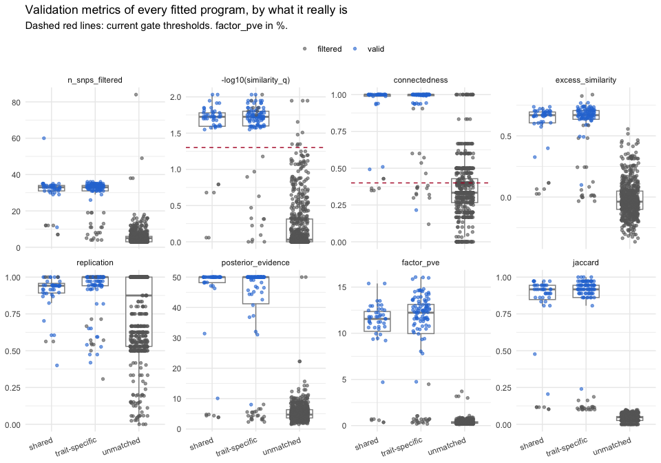

Programs by validation outcome (rows) and what they really are (columns), pooled. A good gate puts shared and trait-specific programs in the ‘valid’ row and unmatched programs everywhere else.

| status | trait-specific | unmatched | shared |
| --- | --- | --- | --- |
| valid | 88 | 0 | 41 |
| low | 1 | 65 | 0 |
| single_trait | 21 | 552 | 6 |

Real programs the gates removed: filtered programs that match a planted program, best match first (up to 20 of 28). Many are fragments of a planted program that EBMF split off.

| version | rep | trait | program | planted_label | jaccard | n_snps_filtered | excess_similarity | excess_connectedness | confidence_tier | replication | posterior_evidence | factor_pve_pct | status |
| --- | --- | --- | --- | --- | --- | --- | --- | --- | --- | --- | --- | --- | --- |
| snp_overlap = 1.00, concordant | 2 | trait B | 4 | specific1_t2 | 0.19 | 34 | 0.014 | 0.011 | low | 0.31 | 8.1 | 4.48 | low |
| snp_overlap = 0.20, concordant | 2 | trait A | 10 | specific2_t1 | 0.16 | 7 | 0.481 | 0.802 | single_trait | 1.00 | 4.4 | 0.40 | single_trait |
| snp_overlap = 0.20, antagonistic | 2 | trait A | 10 | specific2_t1 | 0.16 | 7 | 0.481 | 0.802 | single_trait | 1.00 | 4.4 | 0.40 | single_trait |
| snp_overlap = 0.20, concordant | 1 | trait A | 5 | specific1_t1 | 0.12 | 11 | 0.016 | 0.263 | single_trait | 0.71 | 3.1 | 0.50 | single_trait |
| snp_overlap = 1.00, concordant | 1 | trait B | 4 | specific2_t2 | 0.12 | 11 | 0.123 | 0.285 | single_trait | 1.00 | 3.1 | 0.53 | single_trait |
| snp_overlap = 0.20, antagonistic | 1 | trait A | 5 | specific1_t1 | 0.12 | 11 | 0.016 | 0.263 | single_trait | 0.71 | 3.1 | 0.50 | single_trait |
| snp_overlap = 1.00, antagonistic | 1 | trait B | 4 | specific2_t2 | 0.12 | 11 | 0.057 | 0.233 | single_trait | 1.00 | 3.1 | 0.54 | single_trait |
| snp_overlap = 0.10, concordant | 1 | trait A | 6 | shared1 | 0.12 | 12 | 0.065 | 0.269 | single_trait | 0.56 | 4.4 | 0.58 | single_trait |
| snp_overlap = 1.00, concordant | 1 | trait A | 6 | shared1 | 0.12 | 12 | 0.026 | 0.243 | single_trait | 1.00 | 4.8 | 0.70 | single_trait |
| snp_overlap = 0.10, antagonistic | 1 | trait A | 6 | shared1 | 0.12 | 12 | 0.065 | 0.269 | single_trait | 0.56 | 4.4 | 0.58 | single_trait |
| snp_overlap = 1.00, antagonistic | 1 | trait A | 6 | shared1 | 0.12 | 12 | 0.026 | 0.243 | single_trait | 1.00 | 4.8 | 0.70 | single_trait |
| snp_overlap = 1.00, concordant | 2 | trait B | 5 | specific2_t2 | 0.11 | 13 | 0.007 | 0.210 | single_trait | 0.57 | 4.1 | 0.69 | single_trait |
| snp_overlap = 1.00, antagonistic | 2 | trait B | 4 | specific2_t2 | 0.11 | 13 | 0.008 | 0.208 | single_trait | 0.57 | 4.1 | 0.71 | single_trait |
| snp_overlap = 0.33, concordant | 2 | trait A | 21 | specific2_t1 | 0.11 | 4 | 0.585 | 0.898 | single_trait | 1.00 | 4.5 | 0.29 | single_trait |
| snp_overlap = 0.33, concordant | 2 | trait B | 17 | specific2_t2 | 0.11 | 4 | 0.826 | 0.895 | single_trait | 0.50 | 3.5 | 0.18 | single_trait |
| snp_overlap = 0.33, antagonistic | 2 | trait A | 21 | specific2_t1 | 0.11 | 4 | 0.585 | 0.898 | single_trait | 1.00 | 4.5 | 0.29 | single_trait |
| snp_overlap = 0.33, antagonistic | 2 | trait B | 17 | specific2_t2 | 0.11 | 4 | 0.837 | 0.907 | single_trait | 1.00 | 3.5 | 0.18 | single_trait |
| snp_overlap = 0.20, concordant | 1 | trait B | 9 | specific2_t2 | 0.11 | 5 | 0.244 | 0.488 | single_trait | 0.54 | 5.6 | 0.32 | single_trait |
| snp_overlap = 0.20, antagonistic | 1 | trait B | 9 | specific2_t2 | 0.11 | 5 | 0.243 | 0.486 | single_trait | 0.67 | 5.6 | 0.33 | single_trait |
| snp_overlap = 0.33, concordant | 1 | trait A | 10 | shared1 | 0.10 | 7 | 0.115 | 0.318 | single_trait | 1.00 | 3.8 | 0.36 | single_trait |

No valid program is unmatched: the gates let no noise program through.

**How to read it.**

- **similarity_q and connectedness** decide the tier. Check that shared and trait-specific programs sit above their dashed lines in the figure and unmatched ones below.
- **Replication** is reported, not used for the tier. If shared and trait-specific programs cluster near 1 and unmatched ones spread lower, it separates them; where the two groups overlap, it does not.
- **The two lists** are the direct evidence. Real programs removed by a gate argue for loosening it; noise passing every gate argues for tightening one.
- **Quick mode floors similarity.** With `quick = TRUE` the similarity null uses 300 random SNP sets, so the smallest possible p is about 0.003. The full run uses 10000, which leaves more room.

## 2. Was the shared program found in each trait?

**What this table shows.** For the shared program, in each trait, the share of replicates in which a **valid** program represents it, in which the best program representing it was **filtered** out by validation (with the gates it failed), and in which **no** fitted program represents it at all. The trait- specific programs are shown last, pooled, for comparison.

Discovery of the shared program, per trait. ‘filtered: low’ means the best-matching program was of low confidence; ‘not found’ means no fitted program overlaps the planted loci (Jaccard >= 0.1).

| version | trait | valid |
| --- | --- | --- |
| snp_overlap = 0.10, concordant | trait A | 100% |
| snp_overlap = 0.10, concordant | trait B | 100% |
| snp_overlap = 0.20, concordant | trait A | 100% |
| snp_overlap = 0.20, concordant | trait B | 100% |
| snp_overlap = 0.33, concordant | trait A | 100% |
| snp_overlap = 0.33, concordant | trait B | 100% |
| snp_overlap = 0.66, concordant | trait A | 100% |
| snp_overlap = 0.66, concordant | trait B | 100% |
| snp_overlap = 1.00, concordant | trait A | 100% |
| snp_overlap = 1.00, concordant | trait B | 100% |
| snp_overlap = 0.10, antagonistic | trait A | 100% |
| snp_overlap = 0.10, antagonistic | trait B | 100% |
| snp_overlap = 0.20, antagonistic | trait A | 100% |
| snp_overlap = 0.20, antagonistic | trait B | 100% |
| snp_overlap = 0.33, antagonistic | trait A | 100% |
| snp_overlap = 0.33, antagonistic | trait B | 100% |
| snp_overlap = 0.66, antagonistic | trait A | 100% |
| snp_overlap = 0.66, antagonistic | trait B | 100% |
| snp_overlap = 1.00, antagonistic | trait A | 100% |
| snp_overlap = 1.00, antagonistic | trait B | 100% |

Discovery of the trait-specific programs, pooled over versions and traits.

| family | valid | not found |
| --- | --- | --- |
| null | 100% | 0% |
| shared | 99% | 1% |

**How to read it.** SNP overlap should not change discovery much: each trait’s fit sees only its own matrix, and the shared program is an ordinary program there. If the `valid` column is well below 100%, the shared program is being lost before linking: `filtered: low` means the best-matching program was of low confidence, i.e. its member SNPs are no more alike than random SNP sets of the same size, or it is below the size floor.

## 2b. How closely do the resolved programs match the planted ones?

**What this table shows.** Section 2 counts a planted program as found when a fitted program overlaps it with Jaccard of at least 0.1, which is a low bar. This table shows how close that match actually is. For each planted program, the program that represents it is the best-matching valid program (or, if none is valid, the best-matching program of any status). Its match is then scored four ways:

- **jaccard**: the overlap between its high-confidence SNPs and the planted SNPs, divided by their union.
- **snp_precision**: the share of its high-confidence SNPs that were planted in the program. Below 1 means it has picked up SNPs from elsewhere.
- **snp_recall**: the share of the planted SNPs it recovers as high-confidence members. Below 1 means planted SNPs were missed or went to another program.
- **loading_cor**: the correlation of its SNP loadings, over every locus in the trait, with the planted per-locus effect `a_s` (0 outside the program). This scores the loadings themselves, not just the membership cut.

`n_programs` is the mean number of fitted programs mapped to the planted one. Values above 1 mean EBMF split it.

Match between planted and resolved programs (mean over replicates, Monte Carlo SE). The shared program is shown per version and trait; the trait-specific programs are pooled in the last rows. Scores are over replicates in which some fitted program mapped to the planted one.

| version | trait | jaccard | snp_precision | snp_recall | loading_cor | n_programs |
| --- | --- | --- | --- | --- | --- | --- |
| snp_overlap = 0.10, concordant | trait A | 0.93 (0.01) | 1.00 (0.00) | 0.93 (0.01) | 0.99 (0.00) | 1.5 (0.5) |
| snp_overlap = 0.10, concordant | trait B | 0.97 (0.00) | 1.00 (0.00) | 0.97 (0.00) | 1.00 (0.00) | 1.0 (0.0) |
| snp_overlap = 0.20, concordant | trait A | 0.96 (0.01) | 1.00 (0.00) | 0.96 (0.01) | 0.99 (0.00) | 1.0 (0.0) |
| snp_overlap = 0.20, concordant | trait B | 0.94 (0.03) | 1.00 (0.00) | 0.94 (0.03) | 0.99 (0.00) | 1.0 (0.0) |
| snp_overlap = 0.33, concordant | trait A | 0.92 (0.03) | 1.00 (0.00) | 0.92 (0.03) | 0.99 (0.00) | 1.5 (0.5) |
| snp_overlap = 0.33, concordant | trait B | 0.89 (0.03) | 1.00 (0.00) | 0.89 (0.03) | 0.99 (0.00) | 1.0 (0.0) |
| snp_overlap = 0.66, concordant | trait A | 0.90 (0.04) | 1.00 (0.00) | 0.90 (0.04) | 0.99 (0.00) | 1.0 (0.0) |
| snp_overlap = 0.66, concordant | trait B | 0.89 (0.00) | 1.00 (0.00) | 0.89 (0.00) | 0.99 (0.00) | 1.0 (0.0) |
| snp_overlap = 1.00, concordant | trait A | 0.86 (0.06) | 1.00 (0.00) | 0.86 (0.06) | 0.99 (0.00) | 1.5 (0.5) |
| snp_overlap = 1.00, concordant | trait B | 0.88 (0.04) | 1.00 (0.00) | 0.88 (0.04) | 1.00 (0.00) | 1.0 (0.0) |
| snp_overlap = 0.10, antagonistic | trait A | 0.93 (0.01) | 1.00 (0.00) | 0.93 (0.01) | 0.99 (0.00) | 1.5 (0.5) |
| snp_overlap = 0.10, antagonistic | trait B | 0.93 (0.01) | 1.00 (0.00) | 0.93 (0.01) | 0.99 (0.00) | 1.0 (0.0) |
| snp_overlap = 0.20, antagonistic | trait A | 0.96 (0.01) | 1.00 (0.00) | 0.96 (0.01) | 0.99 (0.00) | 1.0 (0.0) |
| snp_overlap = 0.20, antagonistic | trait B | 0.94 (0.03) | 1.00 (0.00) | 0.94 (0.03) | 1.00 (0.00) | 1.0 (0.0) |
| snp_overlap = 0.33, antagonistic | trait A | 0.92 (0.03) | 1.00 (0.00) | 0.92 (0.03) | 0.99 (0.00) | 1.5 (0.5) |
| snp_overlap = 0.33, antagonistic | trait B | 0.67 (0.19) | 0.76 (0.24) | 0.86 (0.00) | 0.89 (0.10) | 1.5 (0.5) |
| snp_overlap = 0.66, antagonistic | trait A | 0.90 (0.04) | 1.00 (0.00) | 0.90 (0.04) | 0.99 (0.00) | 1.0 (0.0) |
| snp_overlap = 0.66, antagonistic | trait B | 0.89 (0.00) | 1.00 (0.00) | 0.89 (0.00) | 0.99 (0.00) | 1.0 (0.0) |
| snp_overlap = 1.00, antagonistic | trait A | 0.86 (0.06) | 1.00 (0.00) | 0.86 (0.06) | 0.99 (0.00) | 1.5 (0.5) |
| snp_overlap = 1.00, antagonistic | trait B | 0.88 (0.04) | 1.00 (0.00) | 0.88 (0.04) | 0.99 (0.00) | 1.0 (0.0) |
| trait-specific, null version | both | 0.93 (0.02) | 1.00 (0.00) | 0.93 (0.02) | 0.99 (0.00) | 1.1 (0.1) |
| trait-specific, shared versions | both | 0.93 (0.00) | 1.00 (0.00) | 0.93 (0.00) | 0.99 (0.00) | 1.3 (0.1) |

**How to read it.**

- **Precision and recall near 1** mean the resolved program is the planted program, locus for locus.
- **A high loading_cor** means the fitted loadings also track how strongly each locus acts in the program, not only which loci are in it.
- **SNP overlap should not matter here.** Each trait is fitted on its own, so the shared program’s match should look the same at every overlap. A trend with overlap would point to a problem in the simulation, not the fit.
- **Recall well below precision** usually goes with `n_programs` above 1: the planted program was split, and the representative program holds only part of it.

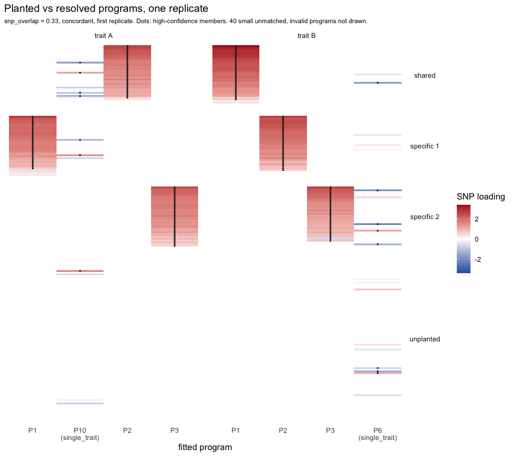

**How to read it.** Each row block is one planted program, plus the loci that belong to no program (“unplanted”). Columns are the fitted programs that are valid or that map to a planted program. Small factors that fail validation and match nothing are left out. A clean recovery is one strong column per planted block, with dots, and pale everywhere else. Two columns sharing a block show a split program. A column lit up across several blocks shows programs merged into one. Dots outside a block’s own column are high-confidence SNPs assigned to the wrong program.

## 3. Was it linked?

**What this table shows.** Linking was run twice on every replicate:

- on **all** fitted programs, the primary analysis;
- on the **valid** programs only, as the gates would have it.

For each setting and program set, the table shows how many links were reported per replicate, the fraction of replicates in which the shared program was linked (`recall`), and the fraction of links that were real (`precision`). Both are given at the strict primary tier and at primary + candidate (`any`).

Link recovery on all fitted programs and on valid programs only (mean over 2 replicates, Monte Carlo SE). recall is whether the shared program was linked; precision is over reported links.

| version | programs | links_any | links_primary | recall_any | recall_primary | precision_any | precision_primary |
| --- | --- | --- | --- | --- | --- | --- | --- |
| snp_overlap = 0.10, concordant | all | 1.0 (0.0) | 1.0 (0.0) | 1.00 (0.00) | 1.00 (0.00) | 1.00 (0.00) | 1.00 (0.00) |
| snp_overlap = 0.10, concordant | valid | 1.0 (0.0) | 1.0 (0.0) | 1.00 (0.00) | 1.00 (0.00) | 1.00 (0.00) | 1.00 (0.00) |
| snp_overlap = 0.20, concordant | all | 1.0 (0.0) | 1.0 (0.0) | 1.00 (0.00) | 1.00 (0.00) | 1.00 (0.00) | 1.00 (0.00) |
| snp_overlap = 0.20, concordant | valid | 1.0 (0.0) | 1.0 (0.0) | 1.00 (0.00) | 1.00 (0.00) | 1.00 (0.00) | 1.00 (0.00) |
| snp_overlap = 0.33, concordant | all | 1.0 (0.0) | 1.0 (0.0) | 1.00 (0.00) | 1.00 (0.00) | 1.00 (0.00) | 1.00 (0.00) |
| snp_overlap = 0.33, concordant | valid | 1.0 (0.0) | 1.0 (0.0) | 1.00 (0.00) | 1.00 (0.00) | 1.00 (0.00) | 1.00 (0.00) |
| snp_overlap = 0.66, concordant | all | 1.5 (0.5) | 1.5 (0.5) | 1.00 (0.00) | 1.00 (0.00) | 0.75 (0.25) | 0.75 (0.25) |
| snp_overlap = 0.66, concordant | valid | 1.0 (0.0) | 1.0 (0.0) | 1.00 (0.00) | 1.00 (0.00) | 1.00 (0.00) | 1.00 (0.00) |
| snp_overlap = 1.00, concordant | all | 1.0 (0.0) | 1.0 (0.0) | 1.00 (0.00) | 1.00 (0.00) | 1.00 (0.00) | 1.00 (0.00) |
| snp_overlap = 1.00, concordant | valid | 1.0 (0.0) | 1.0 (0.0) | 1.00 (0.00) | 1.00 (0.00) | 1.00 (0.00) | 1.00 (0.00) |
| snp_overlap = 0.10, antagonistic | all | 1.0 (0.0) | 1.0 (0.0) | 1.00 (0.00) | 1.00 (0.00) | 1.00 (0.00) | 1.00 (0.00) |
| snp_overlap = 0.10, antagonistic | valid | 1.0 (0.0) | 1.0 (0.0) | 1.00 (0.00) | 1.00 (0.00) | 1.00 (0.00) | 1.00 (0.00) |
| snp_overlap = 0.20, antagonistic | all | 1.0 (0.0) | 1.0 (0.0) | 1.00 (0.00) | 1.00 (0.00) | 1.00 (0.00) | 1.00 (0.00) |
| snp_overlap = 0.20, antagonistic | valid | 1.0 (0.0) | 1.0 (0.0) | 1.00 (0.00) | 1.00 (0.00) | 1.00 (0.00) | 1.00 (0.00) |
| snp_overlap = 0.33, antagonistic | all | 1.5 (0.5) | 1.0 (0.0) | 1.00 (0.00) | 1.00 (0.00) | 1.00 (0.00) | 1.00 (0.00) |
| snp_overlap = 0.33, antagonistic | valid | 1.5 (0.5) | 1.0 (0.0) | 1.00 (0.00) | 1.00 (0.00) | 1.00 (0.00) | 1.00 (0.00) |
| snp_overlap = 0.66, antagonistic | all | 1.0 (0.0) | 1.0 (0.0) | 1.00 (0.00) | 1.00 (0.00) | 1.00 (0.00) | 1.00 (0.00) |
| snp_overlap = 0.66, antagonistic | valid | 1.0 (0.0) | 1.0 (0.0) | 1.00 (0.00) | 1.00 (0.00) | 1.00 (0.00) | 1.00 (0.00) |
| snp_overlap = 1.00, antagonistic | all | 1.0 (0.0) | 1.0 (0.0) | 1.00 (0.00) | 1.00 (0.00) | 1.00 (0.00) | 1.00 (0.00) |
| snp_overlap = 1.00, antagonistic | valid | 1.0 (0.0) | 1.0 (0.0) | 1.00 (0.00) | 1.00 (0.00) | 1.00 (0.00) | 1.00 (0.00) |

**How to read it.** Links are scored on loci only, so a program shared at entirely different variants (overlap 0) cannot be detected by design and is not run. At `snp_overlap = 0.10` the two copies share 4 loci, just above the 3 a link needs, so this is where recall should start to fall. For the valid-only run, compare recall with section 2: it cannot exceed the rate at which the shared program is valid in *both* traits. A recall below that rate is a failure of the link, and a recall at that rate is a failure of discovery. Precision below 1 means links other than the true one were reported. The next table says whether they came from programs the gates would have removed.

Links reported when every fitted program is linked, by whether they are real and by the gate status of the two programs, pooled over replicates. False links between filtered programs are what the gates prevent; true links involving a filtered program are what the gates cost.

| arm | link | both valid | both filtered |
| --- | --- | --- | --- |
| shared versions | false link | 0 | 1 |
| shared versions | true link | 21 | 0 |

False links in the all-programs run, by what the two linked programs really are.

| arm | pair_status | truth_a | truth_b | link_tier | n |
| --- | --- | --- | --- | --- | --- |
| shared versions | both filtered | unmatched | unmatched | primary | 1 |

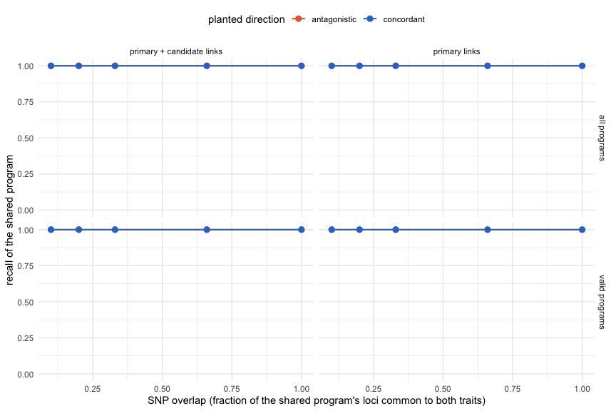

## 4. Was the direction right?

**What this table shows.** For the all-programs run: among real links (primary + candidate), the fraction called in the planted direction, from the sign of `concordance_z` and from `module_rg()`. For the true link itself: the mean `rg`, how often its bootstrap CI excludes 0, and how often `module_rg()` could not estimate it (fewer than 10 usable shared loci).

Sign accuracy on real links by each direction call (mean, Monte Carlo SE), and the module_rg readout for the true link. ci_excludes_zero and mean_rg are over replicates where rg was estimated; undetermined is the share where it was not.

| version | concordance_sign | module_rg | true_links | mean_rg | ci_excludes_zero | undetermined | mean_n_loci_rg |
| --- | --- | --- | --- | --- | --- | --- | --- |
| snp_overlap = 0.10, concordant | 1.00 (0.00) | – | 2 | – | – | 100% | 4.0 (0.0) |
| snp_overlap = 0.20, concordant | 1.00 (0.00) | – | 2 | – | – | 100% | 6.5 (0.5) |
| snp_overlap = 0.33, concordant | 1.00 (0.00) | 1.00 (0.00) | 2 | 0.90 (0.01) | 1.00 (0.00) | 0% | 10.5 (0.5) |
| snp_overlap = 0.66, concordant | 1.00 (0.00) | 1.00 (0.00) | 2 | 0.89 (0.02) | 1.00 (0.00) | 0% | 21.0 (1.0) |
| snp_overlap = 1.00, concordant | 1.00 (0.00) | 1.00 (0.00) | 2 | 0.84 (0.05) | 1.00 (0.00) | 0% | 31.5 (1.5) |
| snp_overlap = 0.10, antagonistic | 0.00 (0.00) | – | 2 | – | – | 100% | 4.0 (0.0) |
| snp_overlap = 0.20, antagonistic | 0.00 (0.00) | – | 2 | – | – | 100% | 6.5 (0.5) |
| snp_overlap = 0.33, antagonistic | 0.00 (0.00) | 1.00 | 2 | -0.92 | 1.00 | 50% | 10.0 (1.0) |
| snp_overlap = 0.66, antagonistic | 0.00 (0.00) | 1.00 (0.00) | 2 | -0.90 (0.02) | 1.00 (0.00) | 0% | 21.0 (1.0) |
| snp_overlap = 1.00, antagonistic | 0.00 (0.00) | 1.00 (0.00) | 2 | -0.89 (0.02) | 1.00 (0.00) | 0% | 31.5 (1.5) |

**How to read it.** The **concordance sign** is expected to read about 1 for concordant and about 0 for antagonistic programs. That is not noise: each trait’s loci are oriented to its own risk allele before fitting, so a shared locus loads positively in both traits’ programs whatever the direction, and the sign of `concordance_z` cannot express antagonism. **`module_rg()`** correlates the two targets’ own effects in a common allele frame, so it should read close to 1 in both directions, with `mean_rg` positive for concordant and negative for antagonistic. It is the direction call used on real data, and the one to trust. `undetermined` should be 100% at overlaps 0.10 and 0.20, which leave 4 and 7 shared loci, below the 10 `module_rg()` needs. It should be 0% from 0.33 up (12 or more). On real data too, links resting on fewer than 10 shared loci get no direction.

## 5. False links when nothing is shared

**What this table shows.** Under the null the two traits have programs of their own and no correspondence, so every reported link is a false discovery.

False links per replicate with nothing shared, on all fitted programs and on valid programs only (Monte Carlo SE in parentheses); any value above 0 is a false discovery.

| programs | tiers | false_links | reps_with_any_link |
| --- | --- | --- | --- |
| all | any | 0.00 (0.00) | 0 of 2 |
| all | primary | 0.00 (0.00) | 0 of 2 |
| valid | any | 0.00 (0.00) | 0 of 2 |
| valid | primary | 0.00 (0.00) | 0 of 2 |

**How to read it.** The trait-specific programs share no loci, so the locus statistic has nothing to score between them, and false links should be essentially 0 at both tiers. Treat this as optimistic: the background is unstructured by default, and a false-discovery rate is only as realistic as the noise it is measured in (see Notes).

## 6. Scale of each comparison

**What this table shows.** How many programs EBMF fitted per trait, and how many of them survived validation, per setting.

Programs fitted and surviving per-trait validation, per version. Each trait carries 1 + K_specific planted programs in the shared versions and K_specific in the null.

| version | fitted_trait_a | valid_trait_a | fitted_trait_b | valid_trait_b |
| --- | --- | --- | --- | --- |
| snp_overlap = 0.10, concordant | 20.5 (0.5) | 3.0 (0.0) | 22.5 (2.5) | 3.0 (0.0) |
| snp_overlap = 0.20, concordant | 24.0 (2.0) | 3.0 (0.0) | 22.0 (1.0) | 3.0 (0.0) |
| snp_overlap = 0.33, concordant | 28.0 (0.0) | 3.0 (0.0) | 22.0 (2.0) | 3.5 (0.5) |
| snp_overlap = 0.66, concordant | 22.0 (0.0) | 3.0 (0.0) | 24.0 (3.0) | 3.0 (0.0) |
| snp_overlap = 1.00, concordant | 23.0 (4.0) | 3.0 (0.0) | 26.0 (4.0) | 3.0 (0.0) |
| snp_overlap = 0.10, antagonistic | 20.5 (0.5) | 3.0 (0.0) | 23.5 (2.5) | 3.0 (0.0) |
| snp_overlap = 0.20, antagonistic | 24.0 (2.0) | 3.0 (0.0) | 19.5 (0.5) | 3.0 (0.0) |
| snp_overlap = 0.33, antagonistic | 28.0 (0.0) | 3.0 (0.0) | 18.5 (1.5) | 3.0 (1.0) |
| snp_overlap = 0.66, antagonistic | 22.0 (0.0) | 3.0 (0.0) | 24.5 (4.5) | 3.0 (0.0) |
| snp_overlap = 1.00, antagonistic | 23.0 (4.0) | 3.0 (0.0) | 27.0 (0.0) | 3.0 (0.0) |
| null: nothing shared | 27.5 (1.5) | 2.0 (0.0) | 19.0 (1.0) | 2.0 (0.0) |

**How to read it.** Each trait carries `1 + K_specific` = 3 planted programs in the shared versions and `K_specific` = 2 in the null. Counts close to those mean EBMF recovered the planted programs almost one-to-one; counts well below mean programs were lost to validation (section 2 says which). The gap between fitted and valid is the noise the gates remove (section 1 shows what it is).

# Notes for interpreting runs

- **One shared program, isolated.** Each planted program has its own driver studies and its own loci, so the fits here are easy. This checks that the pipeline recovers and links a shared program when nothing else interferes; it does not test programs that share driver studies or loci with other programs in the same trait.
- **Recall is credited per planted program, not per link.** EBMF can split one planted program into several factors, so counting links would reward splitting.
- **Sign accuracy is conditional on a real link.** A high value alongside a low recall means the few links found were directionally right, not that direction is well recovered overall.
- **Driver overlap is fixed at 1.** At a shared locus the same background GWAS are present in both traits’ matrices, so the shared program’s driver studies are identical in both. Only SNP overlap varies.
- **Background realism is off by default.** `background_corr` and `snp_pleiotropy_sd` default to 0, the historical independent, random-signed background. The discovery and linking results are largely insensitive to that, but **the null is not**: run the realism arm of the grid script before quoting a false-link rate.
- **Sample overlap is not simulated.** Two real target traits from the same cohort share participants, which biases cross-trait statistics, and `module_rg()` in particular, away from the null.
- **Results are not comparable with earlier renders.** Earlier versions of this document planted antagonism by flipping driver signs and gave the target a flat effect at every locus, and compared a background-study profile axis alongside the locus axis. Effects are now generated in a common allele frame, and only the locus axis is used.